# Repro_Research_CP2

Brian Liswell

12/3/2020

Storms are bad. If you can’t stop them, try to live better with them.

## Synopsis

This project involves exploring the U.S. National Oceanic and Atmospheric Administration’s (NOAA) storm database.

Questions Your data analysis must address the following questions:

**1. Across the United States, which types of events (as indicated in the EVTYPE variable) are most harmful with respect to population health?**

The Dataset has columns for “FATALITIES” and “INJURIES”. Those will be the categories for population health.

**2. Across the United States, which types of events have the greatest economic consequences?**

### 1. Has either a (1) valid RPubs URL pointing to a data analysis document for this assignment been submitted; or (2) a complete PDF file presenting the data analysis been uploaded?

If you are reading this, the answer is yes.

### 2. Is the document written in English?

I don’t want to brag, but I speak English like it’s the first language I learned.

### 6. Is there a section titled “Data Processing” that describes how the data were loaded into R and processed for analysis?

See below, until question 7.

## Data Processing

### Get the data

```r
file_loc <- 'https://d396qusza40orc.cloudfront.net/repdata%2Fdata%2FStormData.csv.bz2'
filename <-'Storm_data.csv.bz2'
download.file(file_loc,filename)
data <- read.csv(filename)

ev_names <- data$EVTYPE
dim(data)
```

```
## [1] 902297     37
```

```r
dim(ev_names)
```

[output not shown]

Most of the columns is needless for this activity. Pair down to just the possibly needed variables.

```r
var_names <- names(data)
names_to_pair <- var_names[c(7,8,22,23,24,25,27)]
# [1] "STATE"      "EVTYPE"     "MAG"        "FATALITIES"
# [5] "INJURIES"   "PROPDMG"    "CROPDMG"
data <- data[names_to_pair]
```

902297 seperate events recorded, asssigned an Event Type. 985 different “Event” Type names. Broadly speaking the Events can be categorized into 7 categories.

```r
var_names <- names(data)
names_to_pair <- var_names[c(7,8,22,23,24,25,27)]


storm_names <-c("wind", "tstm", "tornado", "tropical", "storm", "torrent", "thunder", "hurric", "blizzard")
big_wind_names <-c("tornado", "hurric", "gustnado", "funnel")
precip_names <-c("hail", "rain", "snow", "shower", "precip", "sleet")
mud_names <- c("mud")
flood_names <-c("flood","surf","surge","current")
temper_names <- c("cold","heat","hot","blizzard","freez","frost")
```

```r
get_tf <-function(sub_names,ev_names){
        tf <- logical(length(ev_names))
        for(n in sub_names){
                #print(n)
                temp <- grepl(n,tolower(ev_names))
                tf <-tf + temp
        }
        tf <- tf >0
}
storm_tf <- get_tf(storm_names,ev_names)
big_wind_tf <- get_tf(big_wind_names,ev_names)
precip_tf <- get_tf(precip_names,ev_names)
mud_tf <- get_tf(mud_names,ev_names)
flood_tf <- get_tf(flood_names,ev_names)
temper_tf <- get_tf(temper_names,ev_names)

categ <- character(length(ev_names))
categ[storm_tf] <-"storm"
categ[big_wind_tf] <- "big_wind"
categ[precip_tf] <- "precip"
categ[mud_tf] <- "mud"
categ[flood_tf] <- "flood"
categ[temper_tf] <- "temper"
categ[!nzchar(categ)] <- "other"

data$Broad_categ <- categ
```

Split up the data based on the broad categories. A “pairs” plot on the original “data” takes forever, and might be useless. “pairs” plots on the seperate broad categories also take a long time. Save them to file if you wish. Entire for loop took more than 45 minutes to make files.

```r
data_sub_categ_split <- split(data,data$Broad_categ)
categ_names <- names(data_sub_categ_split)
#
# for(n in categ_names){
#         com <-paste0("pairs(data_sub_categ_split$",n,")")
#         plot_name <- paste0("plot_",n,".png")
#         png(file=plot_name)
#         eval(parse(text = com))
#         dev.off()
# }

# pairs(data_sub_categ_split$other)
```

Now sum INJURIES, FATALITIES, PROPDMG and CROPDMG for the 7 subcategories

```r
FATALITIES <- data.frame(Category = categ_names)
FATALITIES$Total <-0
row.names(FATALITIES) <- categ_names
INJURIES <- FATALITIES
PROPDMG <- FATALITIES
CROPDMG <- FATALITIES

for(n in categ_names){
        FATALITIES[n,"Total"] <- sum(data_sub_categ_split[[n]]$FATALITIES)
        INJURIES[n,"Total"] <- sum(data_sub_categ_split[[n]]$INJURIES)
        PROPDMG[n,"Total"] <- sum(data_sub_categ_split[[n]]$PROPDMG)
        CROPDMG[n,"Total"] <- sum(data_sub_categ_split[[n]]$CROPDMG)
}
```

### 7. Is there a section titled “Results” where the main results are presented?

## Results

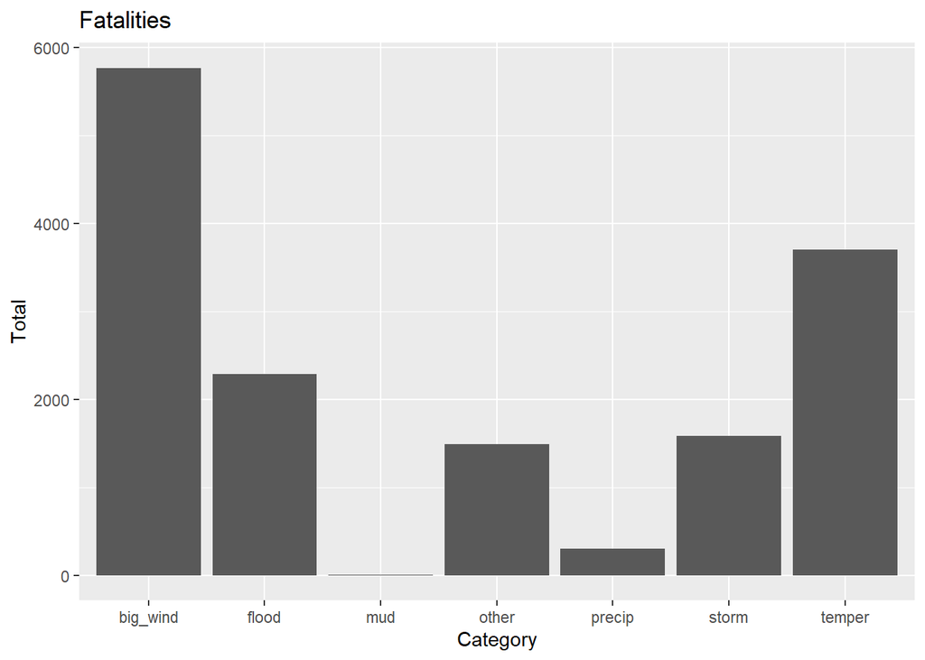

```r
library(ggplot2)
p<-ggplot(data=FATALITIES, aes(x=Category, y=Total)) +
  geom_bar(stat="identity")+ggtitle("Fatalities")
print(p)
```

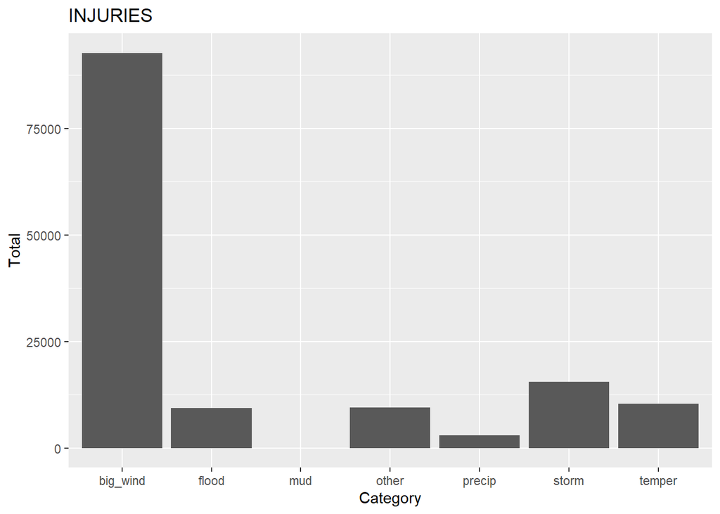

```r
p<-ggplot(data=INJURIES, aes(x=Category, y=Total)) +
  geom_bar(stat="identity")+ggtitle("INJURIES")
print(p)
```

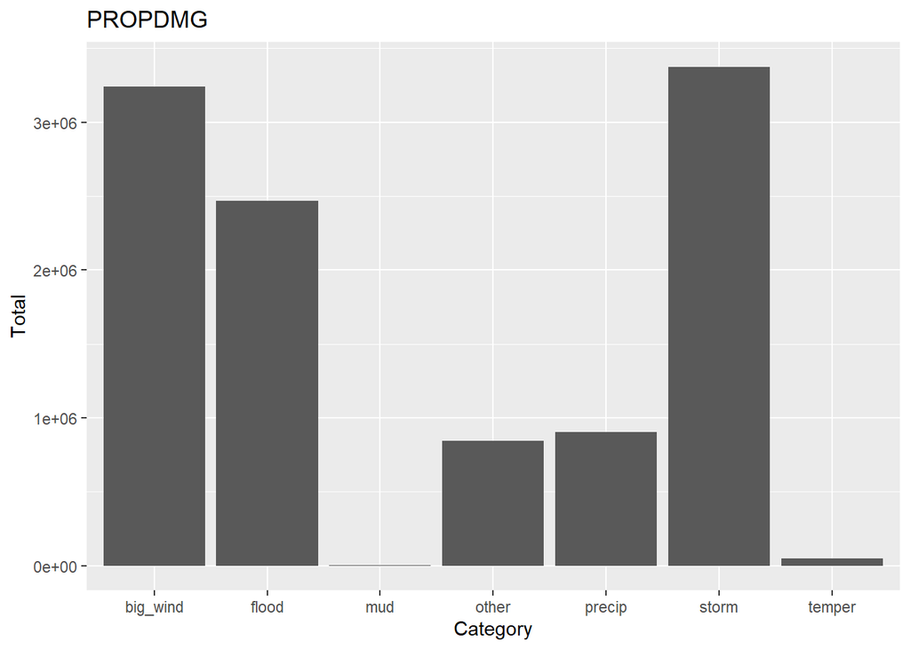

```r
p<-ggplot(data=PROPDMG, aes(x=Category, y=Total)) +
  geom_bar(stat="identity")+ggtitle("PROPDMG")
print(p)
```

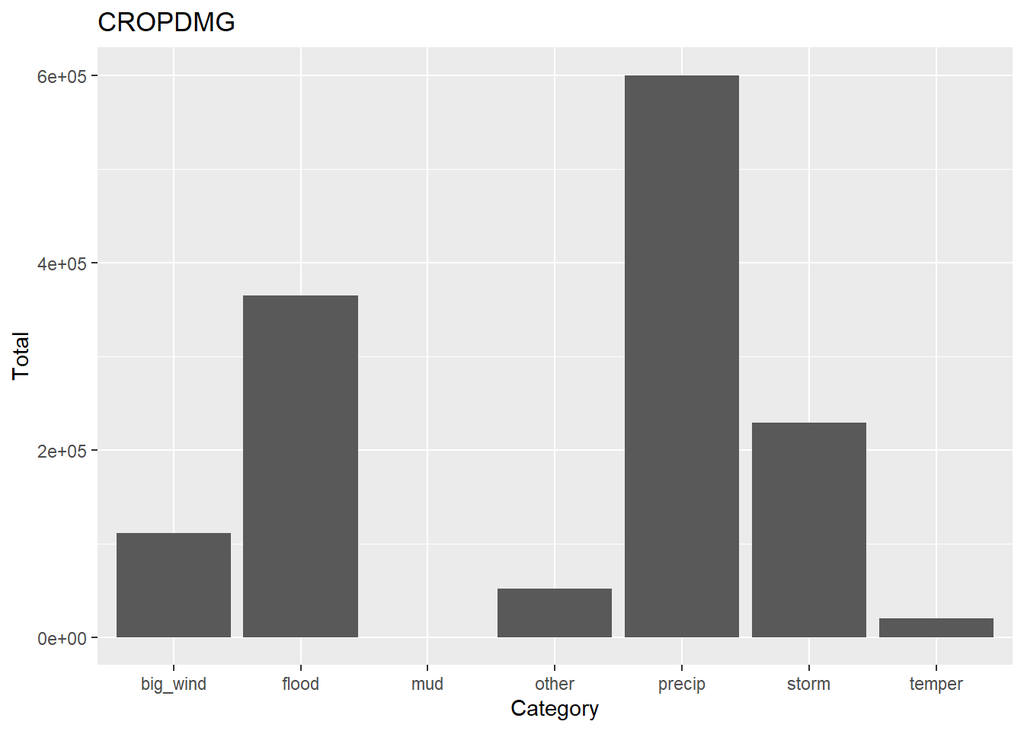

```r
p<-ggplot(data=CROPDMG, aes(x=Category, y=Total)) +
  geom_bar(stat="identity")+ggtitle("CROPDMG")
print(p)
```